# Lista 4

## Importando o conjunto de dados para o R

- O conjunto de dados é constituído por tweets de alguns candidatos à presidência da República nas eleições de 2018, publicados entre 1 de janeiro de 2018 e 31 de dezembro de 2019.

```r
tweets_presidenciaveis <- readr::read_csv("tweets_presidenciaveis.csv")
```

## 1. Criando Índice de Interações no Twitter

- Considerando que as redes sociais tem se tornado cada vez mais relevantes para as campanhas eleitorais, como ferramenta de mobilização e busca de visibilidade, bem como, em alguns casos, como meio de comunicação direta entre candidatos e suas audiências, buscaremos aqui comparar as diferenças de interações no Twitter entre os candidatos à presidência das eleições de 2018. Julgamos que a ferramenta permite diferentes níveis de interação, que possivelmente podem estar associados a intensidades de interesse, mobilização e/ou envolvimento por parte dos respondentes às postagens dos presidenciáveis.

## 1. Criando Índice de Interações no Twitter

- Neste sentido, construímos o “Índice de Interações no Twitter (ITT)”, composto por três variáveis do conjunto de dados: “retweets”, “favorites” e “replies”. A variável “retweets”, que corresponde ao compartilhamento da postagem, e “replies”, que compreende as respostas escritas à postagem, receberam peso 2, enquanto a variável “favorites” recebeu peso 1. A princípio, associamos os maiores pesos no índice ao que consideramos requerer um maior “esforço” individual em relação às postagens. A ideia, com isso, é dimensionar essas interações para uma comparação inicial das diferentes relações dos presidenciáveis com suas audiências a partir da ferramenta.

## 1. Criando Índice de Interações no Twitter

- Assim, ITT = favorites * 1 + retweets * 2 + replies * 2

```r
# Carregando tidyverse
library(tidyverse)

# Criando nova coluna com valores do ITT
tweets_ITT <- tweets_presidenciaveis %>%
  mutate(ITT = favorites + retweets*2 + replies*2)
```

## 2. Testando a confiabilidade do Índice pelo Alfa de Cronbach

- Antes de fazer o cálculo do Alfa de Cronbach para medir a validade do Índice, guardamos as três variáveis utilizadas em um novo objeto

```r
# Selecionando as variáveis que compõem o índice
FRR <- tweets_ITT %>%
  select(favorites, retweets, replies)
```

## 2. Testando a confiabilidade do Índice pelo Alfa de Cronbach

```r
# Calculando Alfa de Cronbach
dados.cronbach <- psych::alpha(FRR)
```

```r
print(dados.cronbach[1])
```

```
## $total
##  raw_alpha std.alpha   G6(smc) average_r      S/N          ase     mean
##  0.4735893 0.9196982 0.9128849  0.792431 11.45303 0.0008324301 3079.515
##        sd  median_r
##  6350.451 0.7515095
```

## 2. Testando a confiabilidade do Índice pelo Alfa de Cronbach

- Como visto, o valor do Alfa de Cronbach para o índice com essas 3 variáveis foi igual a 0,47.
- Trata-se de um valor muito baixo, menor do que o valor mínimo recomendado de 0,6.
- O índice criado, portanto, não é confiável do ponto de vista estatístico.

## 3. Medidas-Resumo

- Calculamos duas medidas de posição (média e mediana) dos Índices de Interações no Twitter para os tweets de cada candidato e criamos um novo objeto com esses valores.

```r
# Calculando a média e a mediana dos índices para tweets de cada candidato
  Medidas_Resumo <- tweets_ITT %>%
  group_by(person) %>%
  summarise(Media = round(mean(ITT),2), Mediana = round(median(ITT),2)) %>%
  arrange(desc(Media)) %>%
  rename(Candidato = person)
```

## 4. Tabela

| Candidato | Media | Mediana |
| --- | --- | --- |
| Bolsonaro | 39149.30 | 32530 |
| Haddad | 11695.62 | 4654 |
| Boulos | 5569.82 | 1452 |
| Lula | 3752.87 | 1164 |
| Ciro | 3656.20 | 1411 |
| Marina | 3017.77 | 1054 |
| Alckmin | 890.14 | 370 |

- De acordo com os valores abaixo, podemos constatar que o ITT varia de 0 a 337347.

```
##     Min.  1st Qu.   Median     Mean  3rd Qu.     Max.
##      0.0    593.8   1950.0  11058.3   9013.0 337347.0
```

- Porém, observando a distância entre a média e a mediana, bem como a distribuição nos quartis, podemos concluir que a maioria dos tweets possui valor de ITT menor que 10000.
- Há um conjunto relativamente pequeno de casos com valor de ITT muito elevado (acima de 10000) que puxa o valor da média para cima.

## 5. Gráficos

- O gráfico a seguir mostra as frequências dos tweets ao longo do tempo (constata-se um maior volume de tweets próximo ao período eleitoral, em outubro de 2018)

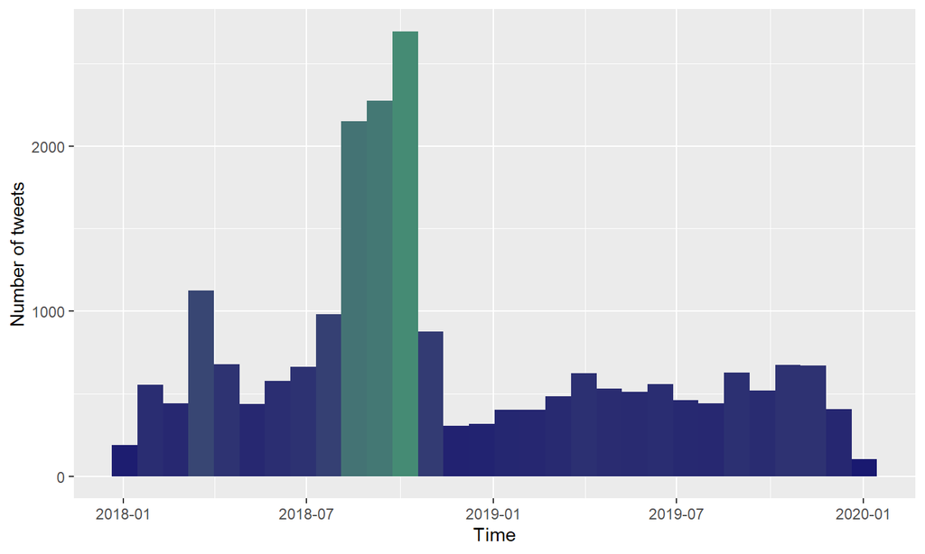

- Além disso, é possível, a partir do gráfico abaixo, verificar a mesma informação para cada um dos candidatos

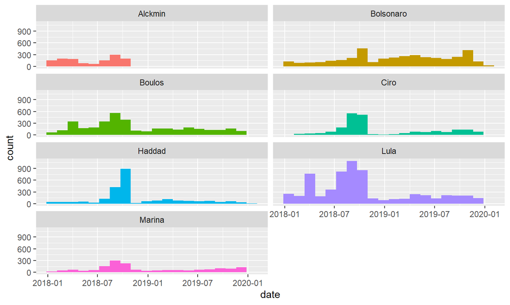

- Também podemos observar a evolução dos valores do Índice ao longo do tempo

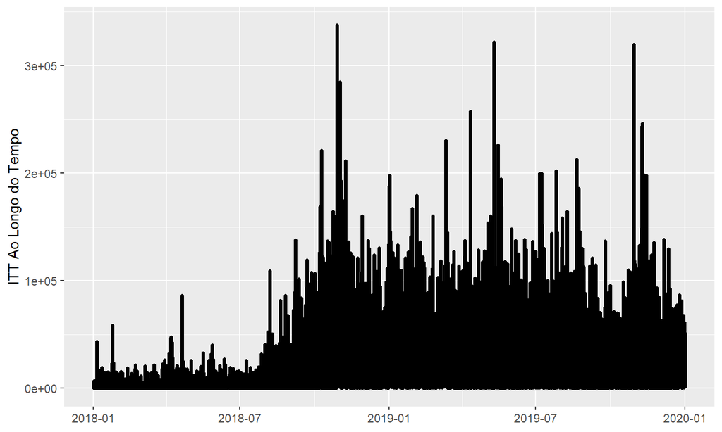